# Motion Picture Prediction Project (MP3)

Daniel Luo, William Peng

# Introduction

In today’s busy world, media and entertainment exists in spades, yet time is an ever valuable commodity. When you open up Netflix or browse the movie catalogue for newly released movies, you’re flooded with a sea of recommendations that leaves your head spinning. Worse - the old adage “don’t knock it ‘till you try it” remains true; how are you supposed to know exactly what you like if you haven’t seen it before? Luckily for you, we’re here to offer a solution never seen before - a revolutionary new way to experience movies - the Motion Picture Prediction Project (MP3).

The inspiration behind the MP3 stems from the need for a better recommendation system that deals with hard numbers and insights and understands the needs of the consumer. Compared to other algorithmic recommendation platforms such as Netflix, we aren’t swayed by potential sponsorships and accept no substitutions when it comes to the quality of our recommendations. We also go beyond the simple figures of movie databases such as IMDb by providing estimated ratings for movies that haven’t even been released using metrics including average rating, movie budget, production companies, spoken languages, and more. This allows our algorithm to accomplish two things - one, it allows users to sort through our massive database of pre-existing movies to filter out the best quality movies based on their preferences, but also allows us to predict the success of future movies (measured in revenue generation and movie rating scores) letting the user know whether the hype is justified or not.

# Data Collection

# Data Preprocessing and Cleaning

Let us start by importing the libraries we need for this section

```python
import pandas as pd
import matplotlib.pyplot as plt
import seaborn as sns
import numpy as np

from scipy.stats import mannwhitneyu, pearsonr, chi2_contingency
from sklearn.preprocessing import StandardScaler, RobustScaler, MinMaxScaler

# Libraries only for the text embedding, commented out to avoid issues
# import torch
# import torch_directml
# from transformers import DistilBertTokenizer, DistilBertModel
# from tqdm import tqdm
```

Load the raw dataset from the csv file.

```python
tmdb_df = pd.read_csv('TMDB_movie_dataset_v11.csv')
```

Here we take a look at the basic information about our dataset in order to determine what we need to fix, what should be dropped, and what needs further processing.

```python
# Basic info
print("Shape:", tmdb_df.shape)
print("\nColumns:", tmdb_df.columns)
```

```
Shape: (1310527, 24)

Columns: Index(['id', 'title', 'vote_average', 'vote_count', 'status', 'release_date',
       'revenue', 'runtime', 'adult', 'backdrop_path', 'budget', 'homepage',
       'imdb_id', 'original_language', 'original_title', 'overview',
       'popularity', 'poster_path', 'tagline', 'genres',
       'production_companies', 'production_countries', 'spoken_languages',
       'keywords'],
      dtype='object')
```

```python
print("\nDtypes:")
tmdb_df.dtypes
```

```
Dtypes:
```

```
id                        int64
title                    object
vote_average            float64
vote_count                int64
status                   object
release_date             object
revenue                   int64
runtime                   int64
adult                      bool
backdrop_path            object
budget                    int64
homepage                 object
imdb_id                  object
original_language        object
original_title           object
overview                 object
popularity              float64
poster_path              object
tagline                  object
genres                   object
production_companies     object
production_countries     object
spoken_languages         object
keywords                 object
dtype: object
```

```python
print("\nInfo:")
tmdb_df.info()
```

```
Info:
<class 'pandas.core.frame.DataFrame'>
RangeIndex: 1310527 entries, 0 to 1310526
Data columns (total 24 columns):
 #   Column                Non-Null Count    Dtype
---  ------                --------------    -----
 0   id                    1310527 non-null  int64
 1   title                 1310511 non-null  object
 2   vote_average          1310527 non-null  float64
 3   vote_count            1310527 non-null  int64
 4   status                1310527 non-null  object
 5   release_date          1047284 non-null  object
 6   revenue               1310527 non-null  int64
 7   runtime               1310527 non-null  int64
 8   adult                 1310527 non-null  bool
```

[output cut: 17 more lines]

```python
# Summary statistics
print("\nSummary:")
display(tmdb_df.describe(include='all').T)
```

```
Summary:
```

|  | count | unique | top | freq | mean | std | min | 25% | 50% | 75% | max |
| --- | --- | --- | --- | --- | --- | --- | --- | --- | --- | --- | --- |
| id | 1310527.0 | NaN | NaN | NaN | 838822.706162 | 446403.553437 | 2.0 | 462674.5 | 850918.0 | 1234295.5 | 1569647.0 |
| title | 1310511 | 1116622 | Home | 179 | NaN | NaN | NaN | NaN | NaN | NaN | NaN |
| vote_average | 1310527.0 | NaN | NaN | NaN | 1.663931 | 2.917643 | 0.0 | 0.0 | 0.0 | 3.25 | 10.0 |
| vote_count | 1310527.0 | NaN | NaN | NaN | 16.370791 | 296.696701 | 0.0 | 0.0 | 0.0 | 1.0 | 34495.0 |
| status | 1310527 | 6 | Released | 1269526 | NaN | NaN | NaN | NaN | NaN | NaN | NaN |
| release_date | 1047284 | 43336 | 2006-01-01 | 3937 | NaN | NaN | NaN | NaN | NaN | NaN | NaN |
| revenue | 1310527.0 | NaN | NaN | NaN | 642551.334129 | 18649900.035943 | -12.0 | 0.0 | 0.0 | 0.0 | 4999999999.0 |
| runtime | 1310527.0 | NaN | NaN | NaN | 45.308544 | 61.062292 | -28.0 | 0.0 | 18.0 | 86.0 | 14400.0 |
| adult | 1310527 | 2 | False | 1181029 | NaN | NaN | NaN | NaN | NaN | NaN | NaN |
| backdrop_path | 334220 | 331119 | /3CxwYgqGtJ6UEGfWUT0gMYCIlFP.jpg | 157 | NaN | NaN | NaN | NaN | NaN | NaN | NaN |
| budget | 1310527.0 | NaN | NaN | NaN | 248522.361207 | 5150563.461748 | 0.0 | 0.0 | 0.0 | 0.0 | 999999999.0 |
| homepage | 136170 | 127430 | https://animation.geidai.ac.jp | 147 | NaN | NaN | NaN | NaN | NaN | NaN | NaN |
| imdb_id | 643732 | 641104 | tt32094375 | 111 | NaN | NaN | NaN | NaN | NaN | NaN | NaN |
| original_language | 1310527 | 177 | en | 713382 | NaN | NaN | NaN | NaN | NaN | NaN | NaN |
| original_title | 1310511 | 1153154 | Untitled | 134 | NaN | NaN | NaN | NaN | NaN | NaN | NaN |
| overview | 1019490 | 987722 |  | 1239 | NaN | NaN | NaN | NaN | NaN | NaN | NaN |
| popularity | 1310527.0 | NaN | NaN | NaN | 1.093847 | 7.076272 | 0.0 | 0.6 | 0.6 | 0.827 | 2994.357 |
| poster_path | 864446 | 859093 | /sRs2R6qI9C3Liv3hWrQTdmoSqqp.jpg | 54 | NaN | NaN | NaN | NaN | NaN | NaN | NaN |
| tagline | 182738 | 175062 | English | 279 | NaN | NaN | NaN | NaN | NaN | NaN | NaN |
| genres | 751386 | 14398 | Documentary | 151842 | NaN | NaN | NaN | NaN | NaN | NaN | NaN |
| production_companies | 570358 | 224966 | Evil Angel | 3074 | NaN | NaN | NaN | NaN | NaN | NaN | NaN |
| production_countries | 694236 | 10683 | United States of America | 192695 | NaN | NaN | NaN | NaN | NaN | NaN | NaN |
| spoken_languages | 718763 | 7350 | English | 256195 | NaN | NaN | NaN | NaN | NaN | NaN | NaN |
| keywords | 334263 | 192402 | short film | 10747 | NaN | NaN | NaN | NaN | NaN | NaN | NaN |

```python
# Missing values
missing = tmdb_df.isnull().sum().sort_values(ascending=False)
missing_pct = (missing / len(tmdb_df) * 100).round(3)
missing_df = pd.DataFrame({'missing_count': missing, 'missing_pct': missing_pct})
print("\nMissing values")
display(missing_df)
```

```
Missing values
```

|  | missing_count | missing_pct |
| --- | --- | --- |
| homepage | 1174357 | 89.610 |
| tagline | 1127789 | 86.056 |
| backdrop_path | 976307 | 74.497 |
| keywords | 976264 | 74.494 |
| production_companies | 740169 | 56.479 |
| imdb_id | 666795 | 50.880 |
| production_countries | 616291 | 47.026 |
| spoken_languages | 591764 | 45.155 |
| genres | 559141 | 42.665 |
| poster_path | 446081 | 34.038 |
| overview | 291037 | 22.208 |
| release_date | 263243 | 20.087 |
| title | 16 | 0.001 |
| original_title | 16 | 0.001 |
| id | 0 | 0.000 |
| vote_average | 0 | 0.000 |
| runtime | 0 | 0.000 |
| revenue | 0 | 0.000 |
| status | 0 | 0.000 |
| vote_count | 0 | 0.000 |
| original_language | 0 | 0.000 |
| budget | 0 | 0.000 |
| adult | 0 | 0.000 |
| popularity | 0 | 0.000 |

Make a copy of the dataframe just in case you need the original data.

```python
clean_df = tmdb_df.copy()
```

Convert release_date to datetime format, we use coerce because we will be dropping all rows which don't have a valid date. Fortunately, the entire dataset uses a consistent date format so we can be confident that any row with na, after this, did not have a release_date.

```python
clean_df['release_date'] = pd.to_datetime(clean_df['release_date'], errors='coerce')
```

Gets the rows in the correct order so that the kept row is the one with the original movie with that title. There are joke entries in this dataset of movies like "Bee Movie" where only the first occurrence is legitimate.

```python
clean_df = clean_df.sort_values(by='id')
```

```python
clean_df.drop_duplicates(subset=['original_title'], keep='first', inplace=True)
```

We drop any adult movies and any movies which have not been released yet, we want to predict values for movies that have been released and don't want movies with other statuses to affect the results.

We also drop any data that we consider to be invalid, movies which lack a release_date or title are dropped because it would be almost impossible to get a decent imputation for those features.

Anything with a runtime <=0 is considered invalid.

```python
clean_df = clean_df.drop(clean_df[(clean_df['adult'] == True) | (clean_df['status'] != 'Released')].index)
clean_df.dropna(subset=['release_date', 'title'], inplace=True)
clean_df.drop(clean_df[(clean_df['runtime'] <= 0) | (clean_df['revenue'] < 0) | (clean_df['release_date'] > pd.Timestamp('2025-10-28'))].index, inplace=True)
```

The date is split into 2 separate, numeric, columns so that it can be used in our following exporatory and final analyses.

```python
clean_df['release_year'] = clean_df['release_date'].dt.year
clean_df['day_of_year'] = clean_df['release_date'].dt.dayofyear
```

'backdrop_path', 'homepage', 'imdb_id', 'poster_path', 'adult' - these are dropped because they contain unimportant data

'tagline' - this is dropped due to having too many missing values at 86% missing

'original_title' - dropped because we didn't want to have to deal with embedding characters from various different languages, this simplifies the embedding process

'status' - dropped because we are only keeping movies with Released status anyway

'release_date' - dropped because it has been replaced by the 2 columns, release_year and day_of_year

```python
# Get rid of unnecessary columns
columns_to_drop = ['backdrop_path', 'homepage', 'imdb_id', 'poster_path', 'tagline', 'original_title', 'adult', 'status', 'release_date']
clean_df.drop(columns=columns_to_drop, inplace=True)
```

## Scaling and Transformations

Because our numerical features have very different ranges of values, we will want to scale some of them.

But before we can scale, a lot of our data is skewed, so we will want to transform them first and then scale.

Revenue, budget, popularity, and vote_count are all likely right skewed data as can be seen by comparing their mean and median from the summary statistics above. So we will log scale them.

```python
# Transform columns using np.log1p to reduce skewness
clean_df[['revenue', 'budget', 'popularity', 'vote_count']] = clean_df[['revenue', 'budget', 'popularity', 'vote_count']].apply(lambda x: np.log1p(x))
```

Now we can scale using the RobustScaler except for revenue, this will be handled differently. This is less effected by outliers which are present in all of them.

```python
rob_scaler = RobustScaler()
```

```python
# Scale the mentioned columns
clean_df[['budget', 'popularity', 'vote_count']] = rob_scaler.fit_transform(clean_df[['budget', 'popularity', 'vote_count']])
```

Since revenue and vote average are our target variables and are extremely zero inflated, we will scale them using MinMaxScaler. This will keep the zero-values as zero while also preventing exploding gradients from the huge numbers in revenue. We want to keep the zero-values at zero because of the classification that we will be doing.

```python
rev_scaler = MinMaxScaler()
va_scaler = MinMaxScaler()
```

```python
clean_df['revenue'] = rev_scaler.fit_transform(clean_df[['revenue']])
clean_df['vote_average'] = va_scaler.fit_transform(clean_df[['vote_average']])
```

As we can see in the plot below, runtime is bimodal, this means that we can't use log transform. Instead that will be scaled with only the RobustScaler.

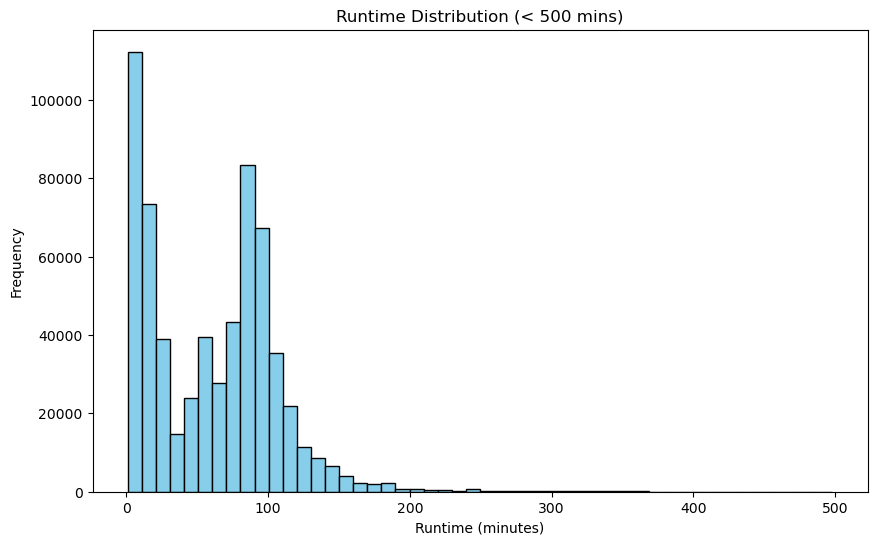

```python
plt.figure(figsize=(10, 6))
clean_df[clean_df['runtime'] < 500]['runtime'].plot(kind='hist', bins=50, color='skyblue', edgecolor='black')
plt.title('Runtime Distribution (< 500 mins)')
plt.xlabel('Runtime (minutes)')
plt.ylabel('Frequency')
plt.show()
```

```python
clean_df[['runtime']] = rob_scaler.fit_transform(clean_df[['runtime']])
```

Finally, the last numerical columns left unscaled and untransformed are the release_year and day_of_year.

release_year can just be StandardScaled. But day_of_year needs more specialized treatment because it is cyclical.

```python
std_scaler = StandardScaler()
```

```python
clean_df['scaled_release_year'] = std_scaler.fit_transform(clean_df[['release_year']])
```

For day_of_year, we will transform it using sin and cos. Using both will help show the cyclical nature of this feature.

```python
days_in_year = 365.25
clean_df['sin_day_of_year'] = np.sin(2 * np.pi * clean_df['day_of_year'] / days_in_year)
clean_df['cos_day_of_year'] = np.cos(2 * np.pi * clean_df['day_of_year'] / days_in_year)
```

Now we can drop the original column

```python
clean_df.drop(columns=['day_of_year'], inplace=True)
```

# Code to generate embeddings

The below code is commented out because it requires a lot of GPU power to run and would likely crash the jupyter notebook kernel. It likely has to be run directly in a .py file.

The code uses distilbert-base-uncased, a lightweight, pre-trained transformers model that generates text embeddings. This was used to embed: ['keywords', 'production_companies', 'production_countries', 'spoken_languages', 'genres', 'overview', 'title', 'original_language'] by combining them all into a single text feature, and then embedding that entire text feature at once.

It runs using Pytorch and DirectML, although with minimal modification, it could also use CUDA instead. The directml was mainly so that it could be run on the local Windows machine.

```python
# def generate_embeddings(texts, tokenizer, model, batch_size=32):
#     model.eval()

#     if torch_directml.is_available():
#         device = torch_directml.device()
#         print("Using DirectML device.")
#     else:
#         raise RuntimeError("DirectML is not available. Please ensure you have the correct setup.")

#     model.to(device)

#     with torch.no_grad():
#         empty_inputs = tokenizer("", return_tensors='pt', truncation=True, padding=True, max_length=512).to(device)
#         empty_outputs = model(**empty_inputs)
#         empty_embedding = empty_outputs.last_hidden_state.mean(dim=1).cpu().numpy()[0]

#     all_embeddings = [None] * len(texts)
#     non_empty_texts = []
#     non_empty_indices = []

#     for i, text in enumerate(texts):
#         if pd.isna(text) or str(text).strip() == "":
#             all_embeddings[i] = empty_embedding
#         else:
#             non_empty_texts.append(str(text))
#             non_empty_indices.append(i)

#     if non_empty_texts:
#         for i in tqdm(range(0, len(non_empty_texts), batch_size), desc="Generating Embeddings for Non-Empty Texts"):
#             batch_texts = non_empty_texts[i:i + batch_size]

#             inputs = tokenizer(
#                 batch_texts,
#                 return_tensors='pt',
#                 truncation=True,
#                 padding=True,
#                 max_length=512
#             ).to(device)

#             with torch.no_grad():
#                 outputs = model(**inputs)

#             last_hidden_state = outputs.last_hidden_state
#             input_mask = inputs['attention_mask']
#             attention_mask = input_mask.unsqueeze(-1)

#             masked_embeddings = last_hidden_state * attention_mask
#             summed_embeddings = masked_embeddings.sum(dim=1)
#             sum_mask = torch.clamp(attention_mask.sum(dim=1), min=1e-9)
#             mean_embeddings = summed_embeddings / sum_mask
#             embeddings = mean_embeddings.cpu().numpy()


#             batch_indices = non_empty_indices[i:i + batch_size]
#             for j, embedding in enumerate(embeddings):
#                 all_embeddings[batch_indices[j]] = embedding

#     return all_embeddings
```

```python
    # tokenizer = DistilBertTokenizer.from_pretrained('distilbert-base-uncased')
    # model = DistilBertModel.from_pretrained('distilbert-base-uncased')

    # clean_df['text_content'] = clean_df.apply(
    #     lambda row: (
    #         f"TITLE: {row['title']} "
    #         f"KEYWORDS: {row['keywords']} "
    #         f"PRODUCTION COMPANIES: {row['production_companies']} "
    #         f"ORIGINAL LANGUAGE: {row['original_language']} "
    #         f"PRODUCTION COUNTRIES: {row['production_countries']} "
    #         f"SPOKEN LANGUAGES: {row['spoken_languages']} "
    #         f"OVERVIEW: {row['overview']}"
    #     ),
    #     axis=1
    # )

    # clean_df.drop(['keywords', 'production_companies', 'production_countries', 'spoken_languages', 'overview', 'title', 'original_language'], axis=1, inplace=True)

    # embeddings = generate_embeddings(
    #     clean_df['text_content'].tolist(),
    #     tokenizer,
    #     model,
    #     batch_size=32
    # )

    # clean_df[f'text_embedding'] = embeddings
    # clean_df.drop(columns=['text_content'], inplace=True)

    # clean_df.to_pickle('clean_tmdb_with_embeddings.pkl')
```

# Data Exploration

## Wilcoxon Rank-Sum Test

We want to know what kind of missing these text based columns have (whether it is Missing Completely at Random, Missing at Random, or Missing Not at Random). We suspect that it is Missing at Random, with the columns mostly relating to the revenue value. A movie which earned more revenue had more people who saw the movie, and thus there are more people who would have filled in the information for these other features in the database that we got our data from.

Now we will take a look at what the distribution of our revenue data looks like to help determine what kind of test we can use.

```python
clean_df['revenue'].describe()
```

```
count    624119.000000
mean          0.016745
std           0.107087
min           0.000000
25%           0.000000
50%           0.000000
75%           0.000000
max           1.000000
Name: revenue, dtype: float64
```

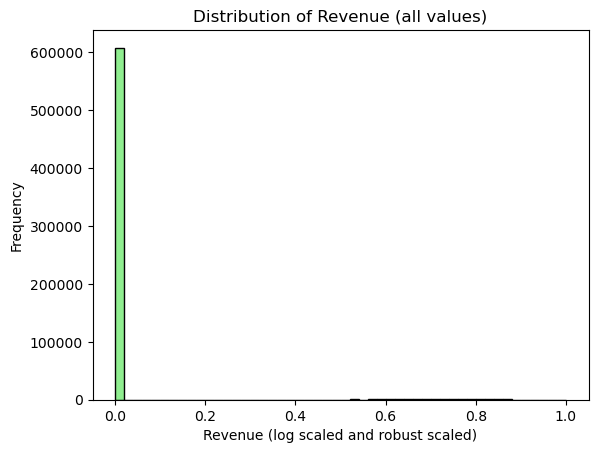

```python
clean_df['revenue'].plot(kind='hist', bins=50, color='lightgreen', edgecolor='black')
plt.xlabel('Revenue (log scaled and robust scaled)')
plt.title('Distribution of Revenue (all values)')
```

We call them "outliers" because the tiny bumps you see off to the right are the only movies with revenue above 0. The vast majority of revenue numbers are 0 both because some movies just don't have known revenues and also due to many movies never making any money at all. This can be seen in the plot below which shows the distribution of revenues above 0.

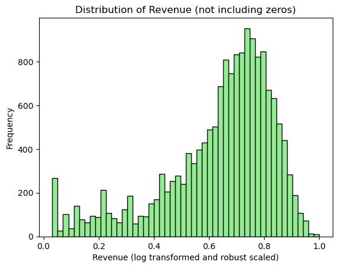

```python
clean_df[clean_df['revenue'] > 0]['revenue'].plot(kind='hist', bins=50, color='lightgreen', edgecolor='black')
plt.xlabel('Revenue (log transformed and robust scaled)')
plt.title('Distribution of Revenue (not including zeros)')
```

The significant amount of zeroes with the nonzero values much further off to the right means that any hypothesis test that assumes normality would not be optimal. In this case, we will instead use the Wilcoxon Rank-Sum Test, a non-parametric test for independent samples. Since we want to know if revenue is higher when values are not missing, we will be performing a right-tailed test.

This gives us the following hypotheses:

H0: The median revenue is the same whether the given column is missing a value or not.

HA: The median revenue is higher when the given column is not missing a value.

We will set our alpha level at 0.05.

```python
alpha = 0.05
```

We only want to test columns that have missing values. Since we dropped the missing values from title and original_language, we don't need to test those columns.

```python
columns_to_test = [
    'keywords',
    'production_companies',
    'production_countries',
    'spoken_languages',
    'genres',
    'overview'
]
```

```python
for column in columns_to_test:
    print(f"HYPOTHESIS TEST FOR COLUMN: '{column}'")
    # print(f"{clean_df['revenue'].isna().sum()}\t{clean_df[column].isna().sum()}")

    revenue_not_empty = clean_df[~(clean_df[column].isna()) & (clean_df['revenue'] != 0)]['revenue']

    revenue_empty = clean_df[(clean_df[column].isna()) & (clean_df['revenue'] != 0)]['revenue']

    stat, p_value = mannwhitneyu(revenue_not_empty, revenue_empty, alternative='greater')

    print(f"  Statistic: {stat}")
    print(f"  P-value: {p_value:.6f}")
```

```
HYPOTHESIS TEST FOR COLUMN: 'keywords'
  Statistic: 32058844.0
  P-value: 0.000000
HYPOTHESIS TEST FOR COLUMN: 'production_companies'
  Statistic: 19475694.0
  P-value: 0.000000
HYPOTHESIS TEST FOR COLUMN: 'production_countries'
  Statistic: 15605308.5
  P-value: 0.000000
HYPOTHESIS TEST FOR COLUMN: 'spoken_languages'
  Statistic: 12062604.0
  P-value: 0.000000
HYPOTHESIS TEST FOR COLUMN: 'genres'
  Statistic: 4373327.0
  P-value: 0.000000
HYPOTHESIS TEST FOR COLUMN: 'overview'
  Statistic: 1737101.5
  P-value: 0.000000
```

The p-values of 0.00000 are significantly under our alpha level of 0.05. This provides significant evidence that we can reject the null hypothesis.

From these hypothesis tests, we have very strong evidence that revenue is higher when there is not a missing value in a text column compared to when there is a missing value. This shows that the missing values in these text columns is Missing at Random. The reason they are missing is related to other observed values (in this case, revenue) in the data.

This means that we cannot just discard rows with missing text data. Instead, we will fill them in with empty strings. This will let the model know that the value was missing.

```python
clean_df[['keywords', 'production_companies', 'production_countries', 'spoken_languages', 'genres', 'overview']] = clean_df[['keywords', 'production_companies', 'production_countries', 'spoken_languages', 'genres', 'overview']].fillna('')
```

## Chi-Square Test of Independence (Genres vs Production Country)

Given that many countries are widely known for being good at making specific genres of movies, the US has Hollywood, famous for producing big-budget action and adventure films, or Japan, famous for its animation (anime), it seems likely that genre and production_countries are not independent. Since these features are categorical, we will use the Chi-Square Test of Independence with the following hypotheses:

H0: The primary genre of a movie and its primary production_country are independent.

HA: The primary genre of a movie and its primary production_country are dependent.

We will again use an alpha of 0.05.

```python
alpha = 0.05
```

We are testing using the "primary" genre and production country. What this means here is that we will be taking the first genre and production country from their respective fields. We will be assuming, for the sake of this test, that the first one listed is the primary one. So we create a separate dataframe specifically to store these temporary features.

```python
chi_sq_df = pd.DataFrame()
chi_sq_df['primary_genre'] = clean_df['genres'].apply(lambda x: x.split(',')[0] if pd.notna(x) and x != '' else 'Unknown')
chi_sq_df['primary_production_country'] = clean_df['production_countries'].apply(lambda x: x.split(',')[0] if pd.notna(x) and x != '' else 'Unknown')
```

Then we create the contingency table:

```python
contingency_table = pd.crosstab(chi_sq_df['primary_genre'], chi_sq_df['primary_production_country'])
```

And finally, we can run the chi-squared test.

```python
chi2_stat, p_value, dof, expected = chi2_contingency(contingency_table)
```

```python
print(f"Chi-Squared Statistic: {chi2_stat:.4f}")
print(f"P-value: {p_value:.4f}")
print(f"Degrees of Freedom: {dof}")
```

```
Chi-Squared Statistic: 245864.1939
P-value: 0.0000
Degrees of Freedom: 4636
```

The following plot shows a heatmap of the residuals for the top 10 genres and production countries

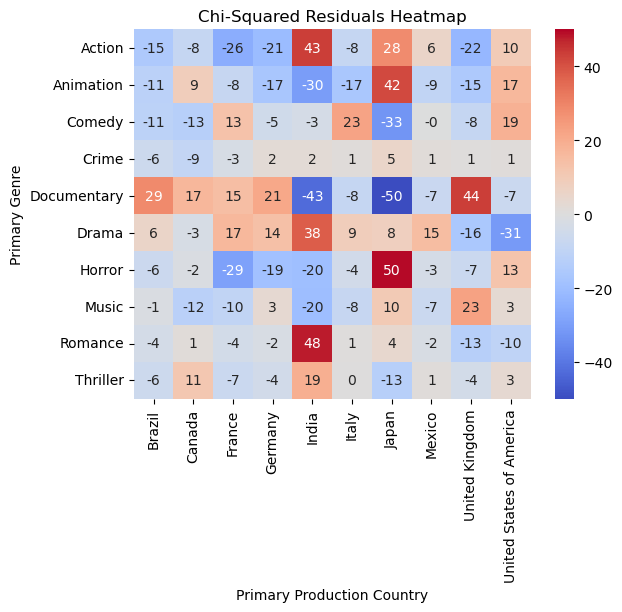

```python
top_10_genres = chi_sq_df[chi_sq_df['primary_genre'] != 'Unknown']['primary_genre'].value_counts().nlargest(10).index
top_10_countries = chi_sq_df[chi_sq_df['primary_production_country'] != 'Unknown']['primary_production_country'].value_counts().nlargest(10).index
filtered_df = chi_sq_df[
    chi_sq_df['primary_genre'].isin(top_10_genres) &
    chi_sq_df['primary_production_country'].isin(top_10_countries)
]

filtered_table = pd.crosstab(filtered_df['primary_genre'], filtered_df['primary_production_country'])

chi2, p, dof, expected = chi2_contingency(filtered_table)

residuals = (filtered_table - expected) / np.sqrt(expected)
sns.heatmap(residuals, fmt=".0f", cmap='coolwarm', annot=True, vmax=50, vmin=-50)
plt.title('Chi-Squared Residuals Heatmap')
plt.xlabel('Primary Production Country')
plt.ylabel('Primary Genre')
plt.show()
```

Furthermore, the p-value of 0 is well under the alpha value we chose of 0.05, meaning that there is statistically significant evidence that the primary genre and production country are not independent. Knowing that these two categorical variables are likely dependent means that if necessary, we can try to optimize our model performance by combining the genre and production_countries features into a single, interaction feature. This could help the final model have more accurate predictions. Especially since our use of a transformers embedding model, distilbert, means that combining the two columns would be relatively simple, and the additional context would actually make a significant difference in how they are embedded.

## Correlation between Revenue and Vote Counts

We suspect that there is a positive relationship between revenue and vote count because the more popular a movie is, the more revenue it should make, and that popularity should also directly affect the number of votes it would get.

This idea provides us with the following hypotheses that we will test in this section.

H0: There is no correlation between a movie's revenue and its vote count.

HA: There is a positive correlation between a movie's revenue and its vote count.

We decided to first look at the correlation heatmap of all the numeric columns.

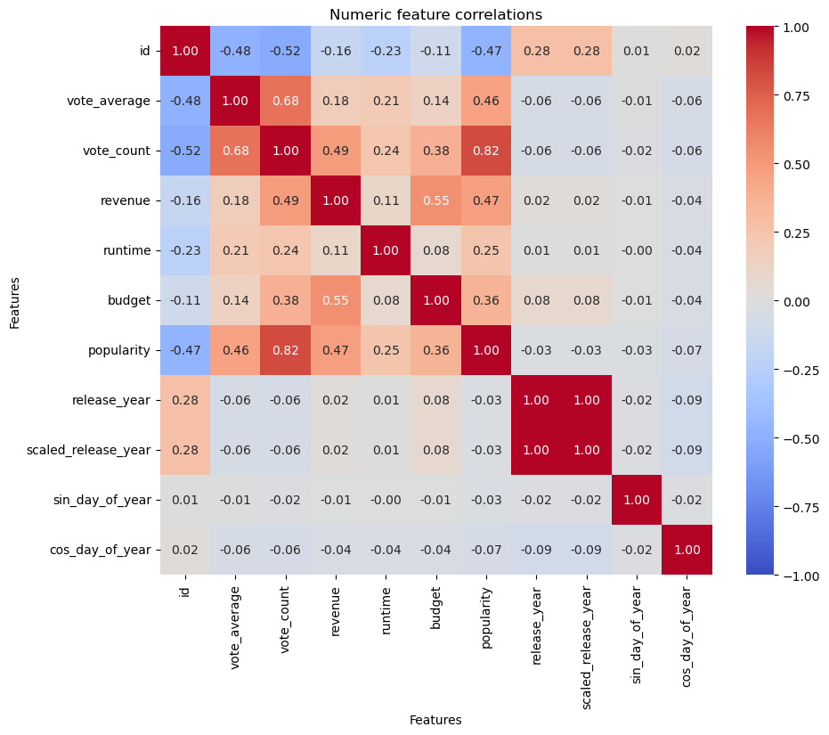

```python
# Correlation heatmap for numeric columns present
num_all = clean_df.select_dtypes(include=['number']).columns.tolist()
if len(num_all) > 1:
    corr = clean_df[num_all].corr()
    plt.figure(figsize=(10,8))
    sns.heatmap(corr, annot=True, fmt='.2f', cmap='coolwarm', center=0, vmax=1, vmin=-1)
    plt.title('Numeric feature correlations')
    plt.xlabel('Features')
    plt.ylabel('Features')
    plt.show()
```

Looking at the heatmaps, we can see that revenue and vote_count have a correlation of 0.49. This is a weak to moderate positive correlation, but we should confirm it by calculating the p-value. We also notice that vote_count and vote_average have an even higher correlation. In order to confirm that this is also statistically significant, we will also perform the test on that with the following, additional hypotheses.

H0: There is no correlation between a movie's vote average and its vote count.

HA: There is a positive correlation between a movie's vote average and its vote count.

We define our alpha to be 0.05 again.

```python
alpha = 0.05
```

```python
correlation, p_value = pearsonr(clean_df['revenue'], clean_df['vote_count'], alternative='greater')
print(f"Correlation between revenue and vote_count: {correlation:.4f}, P-value: {p_value:.6f}")
```

```
Correlation between revenue and vote_count: 0.4904, P-value: 0.000000
```

```python
correlation, p_value = pearsonr(clean_df['vote_average'], clean_df['vote_count'], alternative='greater')
print(f"Correlation between vote_average and vote_count: {correlation:.4f}, P-value: {p_value:.6f}")
```

```
Correlation between vote_average and vote_count: 0.6757, P-value: 0.000000
```

Because both p-values are well below our alpha of 0.05, we have statistically significant evidence that we should reject both null hypotheses. There is support for the ideas that the correlation between revenue/vote_average and vote_count is positive.

Despite the notably high correlation coefficient between vote count and revenue/vote_average, the 2 features we will be predicting, we will still be removing vote_count. The main reason for this is that we want to use the model to predict the vote average and revenue for future movies, meaning that, we will not have vote count data for those movies. While it is a highly correlated metric, it is unfortunately not possible to use when considering future movies.

```python
clean_df.drop(columns=['vote_count'], inplace=True)
```

At the end here, we can get rid of the columns that were left in for convenience when doing the exploratory analysis:

```python
clean_df.drop(columns=['id', 'release_year'], inplace=True)
```

Here is what our formatted, cleaned, and transformed dataset looks like. The text features are not embedded here because that causes jupyter notebook to become incredibly slow and freeze sometimes. In the actual dataset, the text features have already been embedded using distilbert.

```python
clean_df.head()
```

|  | title | vote_average | revenue | runtime | budget | original_language | overview | popularity | genres | production_companies | production_countries | spoken_languages | keywords | scaled_release_year | sin_day_of_year | cos_day_of_year |
| --- | --- | --- | --- | --- | --- | --- | --- | --- | --- | --- | --- | --- | --- | --- | --- | --- |
| 9846 | Ariel | 0.7100 | 0.000000 | 0.118421 | 0.000000 | fi | After the coal mine he works at closes and his... | 5.392931 | Drama, Comedy, Romance | Villealfa Filmproductions | Finland | Finnish | prison, underdog, helsinki, finland, factory w... | -0.400941 | -0.935075 | 0.354450 |
| 9358 | Shadows in Paradise | 0.7199 | 0.000000 | 0.131579 | 0.000000 | fi | Nikander, a rubbish collector and would-be ent... | 4.539193 | Drama, Comedy, Romance | Villealfa Filmproductions | Finland | English, Finnish, Swedish | helsinki, finland, salesclerk, garbage | -0.475358 | -0.962068 | 0.272811 |
| 1819 | Four Rooms | 0.5784 | 0.699489 | 0.447368 | 15.201805 | en | It's Ted the Bellhop's first night on the job.... | 7.175506 | Comedy | Miramax, A Band Apart | United States of America | English | hotel, new year's eve, witch, bet, sperm, hote... | -0.140482 | -0.373477 | 0.927640 |
| 8943 | Judgment Night | 0.6533 | 0.747496 | 0.592105 | 16.860033 | en | While racing to a boxing match, Frank, Mike, J... | 6.828285 | Action, Crime, Thriller | Largo Entertainment, JVC | United States of America | English | drug dealer, chicago, illinois, escape, one ni... | -0.214898 | -0.970882 | 0.239557 |
| 42664 | Life in Loops (A Megacities RMX) | 0.7700 | 0.000000 | 0.210526 | 10.645449 | en | Timo Novotny labels his new project an experim... | 1.485572 | Documentary | inLoops | Austria | English, Hindi, Japanese, Russian, Spanish | megacities | 0.268812 | 0.017202 | 0.999852 |

## Exploratory Data Analysis Conclusion

The overall goal of our movie dataset analysis is to understand how different components of a movie, such as popularity score, date released, or movie budget, can affect the average rating and revenue of a movie, and to be able to create a model that can predict rating and revenue for future movies. In order to make full use of these metrics, we needed to turn these metrics into a usable form, formatting dates, removing extraneous columns, and embedding the text variables into dense vectors using distilbert. We then cleaned the data, removing nonsensical values, like movies with a runtime of 0, and also removing rows which lacked values that we could not fix through imputation, like the missing dates. Scaling and transforming of the data was also performed since the range of the values of the various numeric columns in our data varied quite a bit and we didn't want that to bias the final model. We also filled in missing text fields with empty strings after noticing that the missing values in the text fields were Missing at Random, and thus shouldn't be discarded.

In this exploratory analysis, we prepared our data for use in a model and dove into the data to get an overview of the relationships between the various features in our data, giving us an idea of what we are working with. This helps prepare us for the actual, full analysis of our data.

# Machine Learning Analysis

## Neural Network Architecture

For your convenience, the pickle file containing the pre-cleaned, transformed, and embedded data is included as a pickle file. The code to generate it is included earlier, but is commented out because it crashes Jupyter Notebooks. It will need to be run with a powerful enough GPU and in a plain python file. For this tutorial, we will use the pickle file.

```python
data = pd.read_pickle('clean_tmdb_with_embeddings.pkl')
```

```python
# imports for the machine learning
import torch
import torch_directml
from transformers import DistilBertTokenizer, DistilBertModel
from tqdm.notebook import tqdm
import torch
import torch.nn as nn
import torch.optim as optim
from torch.utils.data import Dataset, DataLoader
from sklearn.model_selection import train_test_split
```

The main issue we face with both of our target variables, revenue and vote average, is that they are significantly zero inflated (if you want to read more on why that is an issue, click [HERE](https://medium.com/@he165076373/understanding-the-zero-inflation-problem-in-data-science-challenges-and-solutions-ee9a21efc0c5)). And, in the case of revenue, there are significant outliers, like Avatar or Avengers Endgame. This makes a normal regression very difficult to do since the model is likely to just predict 0 every time.

So instead of doing a normal regression, we will actually have 4 outputs instead of 2. Two of the outputs will perform the regression, but the other 2 outputs will perform a classification, they will classify whether revenue or vote average is 0 or not.

Another issue is the fact that our text embeddings are essentially 768 features (for more information on the bert model, click [HERE](https://www.geeksforgeeks.org/nlp/explanation-of-bert-model-nlp/)). If we just combine this with the 25 normal features we have, these normal features will be drowned out by the text embeddings in the neural network.

What we will do to deal with that problem is we will have 2 input branches, one which will increase the dimensionality of the normal features while the other compresses the dimensionality of the text embeddings.

Lastly, because we are technically doing 2 different tasks, classification and regression, after the features are all combined together, we will have the network split apart again. One branch will be dedicated to the regression while the other will do all the classification.

```python
class ZeroInflatedMultiTaskModel(nn.Module):
    def __init__(self, text_input_dim=768, normal_input_dim=5):
        super().__init__()

        # Hyperparameters
        self.text_input_dim = text_input_dim
        self.normal_input_dim = normal_input_dim
        self.branch_output_dim = 128 # Both branches end here

        # Text Feature Reduction Branch
        # Reduces the vector dimensions
        self.text_branch = nn.Sequential(
            nn.Linear(self.text_input_dim, 512), # Initial reduction
            nn.ReLU(),
            nn.Dropout(0.2),
            nn.Linear(512, self.branch_output_dim), # Final reduction
            nn.ReLU()
        )

        # Normal Feature Expansion Branch
        # Expands the vector dimensions
        self.normal_branch = nn.Sequential(
            nn.Linear(self.normal_input_dim, 64), # Initial expansion
            nn.ReLU(),
            nn.Dropout(0.2),
            nn.Linear(64, self.branch_output_dim), # Final expansion
            nn.ReLU()
        )

        # Dimensions of text plus normal
        fused_dim = 2 * self.branch_output_dim

        # Trunk A For Classification Zero vs Non Zero
        self.cls_trunk = nn.Sequential(
            nn.Linear(fused_dim, 256),
            nn.ReLU(),
            nn.Dropout(0.3),
            nn.Linear(256, 128),
            nn.ReLU()
        )

        # Trunk B For Regression Value prediction
        self.reg_trunk = nn.Sequential(
            nn.Linear(fused_dim, 256),
            nn.ReLU(),
            nn.Dropout(0.3),
            nn.Linear(256, 128),
            nn.ReLU()
        )

        base_output_dim = 128

        # Output Heads
        # Head Revenue Classification
        self.rev_cls_head = nn.Linear(base_output_dim, 1)

        # Head Revenue Regression
        self.rev_reg_head = nn.Linear(base_output_dim, 1)

        # Head Rating Classification
        self.rate_cls_head = nn.Linear(base_output_dim, 1)

        # Head Rating Regression
        self.rate_reg_head = nn.Linear(base_output_dim, 1)

    def forward(self, text_features, normal_features):
        # Process Text Features
        text_out = self.text_branch(text_features)

        # Process Normal Features
        normal_out = self.normal_branch(normal_features)

        # Feature Fusion Concatenation
        fused_out = torch.cat([text_out, normal_out], dim=1)

        # Split Trunks
        cls_feat = self.cls_trunk(fused_out)
        reg_feat = self.reg_trunk(fused_out)

        # Output Heads
        # Revenue Classification No sigmoid because it is built into BCELoss
        rev_cls_output = self.rev_cls_head(cls_feat)

        # Revenue Regression Linear for unconstrained log scaled value
        rev_reg_output = torch.sigmoid(self.rev_reg_head(reg_feat))

        # Rating Classification No sigmoid because it is built into BCELoss
        rate_cls_output = self.rate_cls_head(cls_feat)

        # Rating Regression Sigmoid to constrain output for Min Max scaled ratings
        rate_reg_output = torch.sigmoid(self.rate_reg_head(reg_feat))

        return rev_cls_output, rev_reg_output, rate_cls_output, rate_reg_output
```

To avoid overfitting, make sure to include dropout layers. Other than the output neurons, all of the rest will just use ReLU as their activation function. It is both fast and sufficient for our use case here.

## Custom Loss Function

Now, the difficult part here is the loss function, we can't just use a premade loss function because we have multiple types of output heads. For our classification heads, we will be using Binary Cross Entropy loss since we are just doing a simple binary classification. For the regression, we will just use MSELoss but with the caveat that the regression loss will only be calculated for training samples where the revenue or vote_average is greater than 0. Essentially, the regression will only be predicting for movies that actually made money or were actually voted on.

For those who need a reminder on what these loss functions are, these links can help provide a quick refresher: [MSE Loss](https://codingnomads.com/mean-squared-error-loss-function) and [BCE Loss](https://towardsdatascience.com/understanding-binary-cross-entropy-log-loss-a-visual-explanation-a3ac6025181a/).

These losses will then be combined according to the 4 new hyperparameters we are adding, called the "loss weights". So our total loss will be:

$L = \lambda_1 \cdot L_1 + \lambda_2 \cdot L_2 + \lambda_3 \cdot L_3 + \lambda_4 \cdot L_4$

```python
def train_model(model, data_loader, optimizer, loss_weights, device):
    model.train()

    bce_rev_loss_fn = nn.BCEWithLogitsLoss()
    bce_rate_loss_fn = nn.BCEWithLogitsLoss()
    reg_loss_fn = nn.MSELoss() # For regression Heads 2 & 4

    total_loss = 0

    progress_bar = tqdm(data_loader, desc=f"Current Epoch: ", leave=True)

    for text_feats, normal_feats, target_rev, target_rate in progress_bar:
        # Move data to the appropriate device CPU GPU
        text_feats = text_feats.to(device, non_blocking=True)
        normal_feats = normal_feats.to(device, non_blocking=True)
        target_rev = target_rev.to(device, non_blocking=True)
        target_rate = target_rate.to(device, non_blocking=True)

        optimizer.zero_grad()

        # Get model predictions
        pred_rev_cls, pred_rev_reg, pred_rate_cls, pred_rate_reg = model(text_feats, normal_feats)

        # Revenue Loss

        # Classification Loss P(Revenue > 0)
        # Create binary target 1 if target > 0, 0 otherwise
        target_rev_cls = (target_rev > 0).float()
        loss_rev_cls = bce_rev_loss_fn(pred_rev_cls.squeeze(), target_rev_cls)

        # Regression Loss Only for non zero targets
        # Create a mask for non zero revenue targets
        rev_mask = (target_rev > 0).squeeze()

        # Apply mask to predictions and targets
        if rev_mask.any():
            loss_rev_reg = reg_loss_fn(
                pred_rev_reg.squeeze()[rev_mask],
                target_rev.squeeze()[rev_mask]
            )
        else:
            loss_rev_reg = torch.tensor(0.0, device=device)

        # Rating Loss

        # Classification Loss P(Rating > 0)
        target_rate_cls = (target_rate > 0).float()
        loss_rate_cls = bce_rate_loss_fn(pred_rate_cls.squeeze(), target_rate_cls)

        # Regression Loss Only for non zero targets
        rate_mask = (target_rate > 0).squeeze()

        # Apply mask to predictions and targets
        if rate_mask.any():
            loss_rate_reg = reg_loss_fn(
                pred_rate_reg.squeeze()[rate_mask],
                target_rate.squeeze()[rate_mask]
            )
        else:
            loss_rate_reg = torch.tensor(0.0, device=device)

        # Total Weighted Loss
        total_loss_batch = (
            loss_weights[0] * loss_rev_cls +
            loss_weights[1] * loss_rev_reg +
            loss_weights[2] * loss_rate_cls +
            loss_weights[3] * loss_rate_reg
        )

        # Backward pass and optimization
        total_loss_batch.backward()
        torch.nn.utils.clip_grad_norm_(model.parameters(), max_norm=1.0)
        optimizer.step()

        current_loss = total_loss_batch.item()
        total_loss += total_loss_batch.item()

        progress_bar.set_postfix({'batch_loss': f'{current_loss:.4f}'})

    return total_loss / len(data_loader)
```

## Setup for Training

Now we will create the Dataset class, we will store our data as numpy arrays for efficiency.

```python
class ZeroInflatedMultiTaskDataset(Dataset):
    def __init__(self, X_text, X_normal, y_revenue, y_rating):
        # Convert all pandas data to numpy float32
        # Features
        if isinstance(X_text, pd.Series):
            X_text = np.stack(X_text.values).astype(np.float32)
        self.text_feats = np.array(X_text, dtype=np.float32)

        self.normal_feats = np.array(X_normal.values, dtype=np.float32)

        # Targets
        self.target_rev = np.array(y_revenue.values, dtype=np.float32)
        self.target_rate = np.array(y_rating.values, dtype=np.float32)

        # Verify matching lengths just in case
        assert len(self.text_feats) == len(self.normal_feats) == len(self.target_rev)

    def __len__(self):
        return len(self.text_feats)

    def __getitem__(self, idx):
        # The order must match the expected order in the train_model function:
        # text_feats, normal_feats, target_rev, target_rate
        return (
            self.text_feats[idx],
            self.normal_feats[idx],
            self.target_rev[idx],
            self.target_rate[idx]
        )
```

Now we need to get our features (X) and targets (y). Remember to drop the 'id' and 'release_year' columns, they were kept in the dataset just to make it easier to make modifications, they can not be used in the actual training.

```python
X = data.drop(['revenue', 'vote_average', 'revenue_classification', 'vote_average_classification', 'id', 'release_year'], axis=1)
y = data[['revenue', 'vote_average']]
```

We then split the data into the two different types of inputs, and also split up the two outputs. Then use train_test_split to get our training and test sets.

```python
X_normal = X.drop(['text_embedding'], axis=1)
X_text = X['text_embedding']

y_revenue = y['revenue']
y_rating = y['vote_average']
```

```python
(X_text_train, X_text_test,
 X_normal_train, X_normal_test,
 y_rev_train, y_rev_test,
 y_rate_train, y_rate_test) = train_test_split(
    X_text, X_normal, y_revenue, y_rating,
    test_size=0.2, random_state=42
)
```

```python
train_dataset = ZeroInflatedMultiTaskDataset(
    X_text_train, X_normal_train, y_rev_train, y_rate_train
)

test_dataset = ZeroInflatedMultiTaskDataset(
    X_text_test, X_normal_test, y_rev_test, y_rate_test
)
```

Now we need to initialize our model and also move our model onto our GPU. The next line is the one you will have to change depending on what you are using to run the network. It is currently on directml, which is for Windows.

```python
device = torch_directml.device()
```

Instantiate the model.

```python
model = ZeroInflatedMultiTaskModel(text_input_dim=768, normal_input_dim=25)
```

Move it to the GPU.

```python
model.to(device)
```

```
Dropped Escape call with ulEscapeCode : 0x03007703
```

```
ZeroInflatedMultiTaskModel(
  (text_branch): Sequential(
    (0): Linear(in_features=768, out_features=512, bias=True)
    (1): ReLU()
    (2): Dropout(p=0.2, inplace=False)
    (3): Linear(in_features=512, out_features=128, bias=True)
    (4): ReLU()
  )
  (normal_branch): Sequential(
    (0): Linear(in_features=25, out_features=64, bias=True)
    (1): ReLU()
    (2): Dropout(p=0.2, inplace=False)
    (3): Linear(in_features=64, out_features=128, bias=True)
    (4): ReLU()
  )
  (cls_trunk): Sequential(
    (0): Linear(in_features=256, out_features=256, bias=True)
    (1): ReLU()
    (2): Dropout(p=0.3, inplace=False)
    (3): Linear(in_features=256, out_features=128, bias=True)
    (4): ReLU()
  )
  (reg_trunk): Sequential(
    (0): Linear(in_features=256, out_features=256, bias=True)
    (1): ReLU()
    (2): Dropout(p=0.3, inplace=False)
    (3): Linear(in_features=256, out_features=128, bias=True)
    (4): ReLU()
  )
  (rev_cls_head): Linear(in_features=128, out_features=1, bias=True)
  (rev_reg_head): Linear(in_features=128, out_features=1, bias=True)
  (rate_cls_head): Linear(in_features=128, out_features=1, bias=True)
  (rate_reg_head): Linear(in_features=128, out_features=1, bias=True)
)
```

Now we set up some of the other things we will need, including our optimizer. We will use the Adam optimizer here.

```python
optimizer = optim.Adam(model.parameters(), lr=1e-3)
```

The following loss weights seem to work pretty well but this is something you can play around with.

```python
loss_weights = [
    1.0,
    10.0,
    1.0,
    10.0
]
```

Now, there's just one more problem to deal, the fact that the dataset is almost overwhelmingly zeros for revenue.

```python
count_zeros = (y_rev_train == 0).sum()
count_ones = (y_rev_train > 0).sum()

print(count_zeros, count_ones)
```

```
486155 13140
```

In order to make sure our model sees enough non-zero revenue training samples, we will implement weighted sampling. This way, in each batch, the model will see a 50/50 split of non-zero revenue and zero revenue samples.

```python
from torch.utils.data import WeightedRandomSampler

# Weight for class 0
weight_0 = 1.0 / count_zeros
# Weight for class 1
weight_1 = 1.0 / count_ones

# 2. Assign a weight to every single sample in the training set
sample_weights = np.where(y_rev_train > 0, weight_1, weight_0)

# 3. Convert to Tensor
sample_weights = torch.from_numpy(sample_weights).double()

# 4. Create the Sampler
sampler = WeightedRandomSampler(
    weights=sample_weights,
    num_samples=len(sample_weights),
    replacement=True
)
```

```python
BATCH_SIZE = 2048

train_loader = DataLoader(
    train_dataset,
    batch_size=BATCH_SIZE,
    shuffle=False,
    sampler=sampler,
    num_workers=4,
    pin_memory=True,
    persistent_workers=True
)

test_loader = DataLoader(
    test_dataset,
    batch_size=BATCH_SIZE * 2,
    shuffle=False,
    num_workers=4,
    pin_memory=True,
    persistent_workers=True
)

num_epochs = 10
```

Create a variable to store the average loss of each epoch.

```python
losses = []
```

## Training

Run the training.

```python
for epoch in range(num_epochs):
    epoch_loss = train_model(
        model=model,
        data_loader=train_loader,
        optimizer=optimizer,
        loss_weights=loss_weights,
        device=device
    )

    losses.append(epoch_loss)

    print(f"Epoch {epoch+1}/{num_epochs}, Average Training Loss: {epoch_loss:.4f}")
```

[output not shown]

## Evaluation of Model Performance

Something important for our model, is that because of the way it is set up, the threshold for the classification can't be 0.5. In order to find the "optimal" threshold, basically the threshold which maximizes the f1 score, the following code has been provided.

Though, it is important to note that depending on the use case, it might be better to maximize recall or precision rather than f1-score.

```python
from sklearn.metrics import f1_score, precision_score, recall_score
import numpy as np
import torch

def optimize_threshold(y_true, y_probs, task_name="Classification"):
    """
    Helper function to iterate over thresholds and find the best F1 score.
    """
    print("\n" + "="*40)
    print(f"{task_name.upper()} - THRESHOLD OPTIMIZATION (F1-Score)")
    print("="*40)

    best_thresh = 0
    best_f1 = 0

    # Test thresholds from 0.05 to 0.95
    for thresh in np.arange(0.05, 0.96, 0.01):
        preds = (np.array(y_probs) > thresh).astype(int)

        # Calculate metrics
        score = f1_score(y_true, preds, zero_division=0)
        prec = precision_score(y_true, preds, zero_division=0)
        rec = recall_score(y_true, preds, zero_division=0)

        # Print row
        if int((thresh * 100) % 10) == 0:
            print(f"Thresh {thresh:.2f} | F1: {score:.4f} | Prec: {prec:.4f} | Recall: {rec:.4f}")

        # Track best
        if score > best_f1:
            best_f1 = score
            best_thresh = thresh

    print(f"\nOptimal {task_name} Threshold: {best_thresh:.2f} (Max F1: {best_f1:.4f})")
    return best_thresh

def advanced_evaluation(model, data_loader, device, minmax_scaler):
    model.eval()

    # Revenue Regression
    true_rev_vals = []
    pred_rev_vals = []

    # Revenue Classification
    true_rev_cls = []
    pred_rev_probs = []

    # Rating Classification
    true_rate_cls = []
    pred_rate_probs = []

    with torch.no_grad():
        for text_feats, normal_feats, target_rev, target_rate in data_loader:
            text_feats = text_feats.to(device, non_blocking=True)
            normal_feats = normal_feats.to(device, non_blocking=True)

            # Forward Pass
            p_rev_cls, p_rev_reg, p_rate_cls, p_rate_reg = model(text_feats, normal_feats)

            # Collect Revenue Classification Data
            probs_rev = torch.sigmoid(p_rev_cls).cpu().numpy().flatten()
            pred_rev_probs.extend(probs_rev)
            true_rev_cls.extend((target_rev.cpu().numpy() > 0).astype(int))

            # Collect Rating Classification Data
            probs_rate = torch.sigmoid(p_rate_cls).cpu().numpy().flatten()
            pred_rate_probs.extend(probs_rate)
            true_rate_cls.extend((target_rate.cpu().numpy() > 0).astype(int))

            # Collect Revenue Regression Data (Only for Actual > 0)
            mask = target_rev.cpu().numpy() > 0
            if mask.any():
                # Get raw 0-1 predictions
                p_reg = p_rev_reg.cpu().numpy().flatten()[mask]
                t_reg = target_rev.cpu().numpy()[mask]

                # Reshape for scaler
                p_reshaped = p_reg.reshape(-1, 1)
                t_reshaped = t_reg.reshape(-1, 1)

                # Inverse MinMax -> Inverse Log
                p_log = minmax_scaler.inverse_transform(p_reshaped)
                t_log = minmax_scaler.inverse_transform(t_reshaped)

                pred_rev_vals.extend(np.expm1(p_log).flatten())
                true_rev_vals.extend(np.expm1(t_log).flatten())

    # Revenue Classification Threshold
    rev_thresh = optimize_threshold(true_rev_cls, pred_rev_probs, task_name="Revenue")

    # Rating Classification Threshold
    rate_thresh = optimize_threshold(true_rate_cls, pred_rate_probs, task_name="Rating")

    return rev_thresh, rate_thresh
```

The next bit of code helps you evaluate the performance of the model by printing some useful metrics. "evaluate_model" is a function that will help take the output from the model and make it usable for analysis. One of the main things is that it performs the sigmoid on the output from the classification heads (which is missing from the model due to the usage of BCE with logits loss which has a built in sigmoid) before classifying the results according to the threshold you pass in.

```python
from sklearn.metrics import accuracy_score, precision_score, recall_score, mean_absolute_error, mean_squared_error, confusion_matrix, roc_auc_score, classification_report, median_absolute_error

def evaluate_model(model, data_loader, device, rev_thresh, rate_thresh):
    model.eval()

    results = {
        'rev_cls_true': [], 'rev_cls_pred': [], 'rev_cls_prob': [],
        'rev_reg_true': [], 'rev_reg_pred': [],
        'rate_cls_true': [], 'rate_cls_pred': [], 'rate_cls_prob': [],
        'rate_reg_true': [], 'rate_reg_pred': []
    }

    with torch.no_grad():
        for text_feats, normal_feats, target_rev, target_rate in data_loader:
            text_feats = text_feats.to(device, non_blocking=True)
            normal_feats = normal_feats.to(device, non_blocking=True)

            # Forward pass
            p_rev_cls, p_rev_reg, p_rate_cls, p_rate_reg = model(text_feats, normal_feats)

            # Process Predictions

            # Revenue Classification
            rev_probs = torch.sigmoid(p_rev_cls).cpu().numpy().flatten()
            results['rev_cls_prob'].extend(rev_probs)
            results['rev_cls_pred'].extend((rev_probs > rev_thresh).astype(int))
            results['rev_cls_true'].extend((target_rev.cpu().numpy() > 0).astype(int))

            # Revenue Regression
            results['rev_reg_pred'].extend(p_rev_reg.cpu().numpy().flatten())
            results['rev_reg_true'].extend(target_rev.cpu().numpy())

            # Rating Classification
            rate_probs = torch.sigmoid(p_rate_cls).cpu().numpy().flatten()
            results['rate_cls_prob'].extend(rate_probs)
            results['rate_cls_pred'].extend((rate_probs > rate_thresh).astype(int))
            results['rate_cls_true'].extend((target_rate.cpu().numpy() > 0).astype(int))

            # Rating Regression
            results['rate_reg_pred'].extend(p_rate_reg.cpu().numpy().flatten())
            results['rate_reg_true'].extend(target_rate.cpu().numpy())

    return {k: np.array(v) for k, v in results.items()}

def print_metrics(results, rev_scaler):
    print("="*40)
    print("      MODEL PERFORMANCE REPORT")
    print("="*40)

    # Revenue Classification
    acc_rev = accuracy_score(results['rev_cls_true'], results['rev_cls_pred'])
    auc_rev = roc_auc_score(results['rev_cls_true'], results['rev_cls_prob'])
    print(f"\n[Head 1] Revenue Classification (Zero vs Non-Zero):")
    print(f"  Accuracy: {acc_rev:.4f}")
    print(f"  AUC-ROC:  {auc_rev:.4f}")

    print(classification_report(results['rev_cls_true'], results['rev_cls_pred']))

    # Revenue Regression
    # Only evaluate regression on items that actually had revenue > 0
    mask_rev = results['rev_reg_true'] > 0
    if mask_rev.sum() > 0:
        pred_0to1 = results['rev_reg_pred'][mask_rev]
        true_0to1 = results['rev_reg_true'][mask_rev]

        mse = mean_squared_error(true_0to1, pred_0to1)
        print(f"\n[Head 2] Revenue Regression:")
        print(f"  MSE (0-1 Scale): {mse:.4f}")

        pred_reshaped = pred_0to1.reshape(-1, 1)
        true_reshaped = true_0to1.reshape(-1, 1)

        # Recover the original input to the scaler
        pred_log = rev_scaler.inverse_transform(pred_reshaped)
        true_log = rev_scaler.inverse_transform(true_reshaped)

        # Log -> Dollars
        pred_dollars = np.expm1(pred_log)
        true_dollars = np.expm1(true_log)

        mae = median_absolute_error(true_dollars, pred_dollars)
        print(f"  Median Absolute Error (Dollars): ${mae:,.2f}")

    # Rating Classification
    acc_rate = accuracy_score(results['rate_cls_true'], results['rate_cls_pred'])
    print(f"\n[Head 3] Rating Classification (Rated vs Unrated):")
    print(f"  Accuracy: {acc_rate:.4f}")

    print(classification_report(results['rate_cls_true'], results['rate_cls_pred']))

    # Rating Regression
    mask_rate = results['rate_reg_true'] > 0
    if mask_rate.sum() > 0:
        true_rate = results['rate_reg_true'][mask_rate]
        pred_rate = results['rate_reg_pred'][mask_rate]

        mae_rate = mean_absolute_error(true_rate, pred_rate)

        print(f"\n[Head 4] Rating Regression:")
        print(f"  MAE: {mae_rate:.4f} (Scale 0-1)")
    else:
        print("\n[Head 4] No non-zero rating samples in test set.")
```

In this case, we will get the optimal thresholds from advanced_evaluation.

```python
rev_thresh, rate_thresh = advanced_evaluation(model, test_loader, device, rev_scaler)
```

```
========================================
REVENUE - THRESHOLD OPTIMIZATION (F1-Score)
========================================
Thresh 0.10 | F1: 0.3334 | Prec: 0.2048 | Recall: 0.8962
Thresh 0.20 | F1: 0.3686 | Prec: 0.2336 | Recall: 0.8741
Thresh 0.30 | F1: 0.3950 | Prec: 0.2565 | Recall: 0.8578
Thresh 0.40 | F1: 0.4179 | Prec: 0.2776 | Recall: 0.8443
Thresh 0.50 | F1: 0.4385 | Prec: 0.2984 | Recall: 0.8265
Thresh 0.60 | F1: 0.4641 | Prec: 0.3247 | Recall: 0.8133
Thresh 0.70 | F1: 0.4884 | Prec: 0.3540 | Recall: 0.7872
Thresh 0.80 | F1: 0.5271 | Prec: 0.4085 | Recall: 0.7427
Thresh 0.90 | F1: 0.5816 | Prec: 0.5671 | Recall: 0.5969

Optimal Revenue Threshold: 0.91 (Max F1: 0.5859)

========================================
RATING - THRESHOLD OPTIMIZATION (F1-Score)
========================================
Thresh 0.10 | F1: 0.6407 | Prec: 0.4758 | Recall: 0.9805
Thresh 0.20 | F1: 0.7124 | Prec: 0.5871 | Recall: 0.9057
Thresh 0.30 | F1: 0.7470 | Prec: 0.6881 | Recall: 0.8169
Thresh 0.40 | F1: 0.7480 | Prec: 0.7645 | Recall: 0.7322
Thresh 0.50 | F1: 0.7291 | Prec: 0.8257 | Recall: 0.6528
Thresh 0.60 | F1: 0.6915 | Prec: 0.8723 | Recall: 0.5727
Thresh 0.70 | F1: 0.6393 | Prec: 0.9134 | Recall: 0.4917
Thresh 0.80 | F1: 0.5672 | Prec: 0.9473 | Recall: 0.4048
Thresh 0.90 | F1: 0.4616 | Prec: 0.9744 | Recall: 0.3025

Optimal Rating Threshold: 0.34 (Max F1: 0.7511)
```

Then evaluate the model using the test data

```python
test_results = evaluate_model(model, test_loader, device, rev_thresh, rate_thresh)
```

And now, print the metrics and see how your model did.

```python
print_metrics(test_results, rev_scaler)
```

```
========================================
      MODEL PERFORMANCE REPORT
========================================

[Head 1] Revenue Classification (Zero vs Non-Zero):
  Accuracy: 0.9788
  AUC-ROC:  0.9620
              precision    recall  f1-score   support

           0       0.99      0.99      0.99    121567
           1       0.60      0.57      0.59      3257

    accuracy                           0.98    124824
   macro avg       0.79      0.78      0.79    124824
weighted avg       0.98      0.98      0.98    124824


[Head 2] Revenue Regression:
  MSE (0-1 Scale): 0.0161
  Median Absolute Error (Dollars): $2,717,730.00

[Head 3] Rating Classification (Rated vs Unrated):
  Accuracy: 0.7846
              precision    recall  f1-score   support

           0       0.84      0.79      0.81     72999
           1       0.72      0.78      0.75     51825

    accuracy                           0.78    124824
   macro avg       0.78      0.78      0.78    124824
weighted avg       0.79      0.78      0.79    124824


[Head 4] Rating Regression:
  MAE: 0.1198 (Scale 0-1)
```

Now we want to test our model on data that wasn't even in our dataset when we first got it. Loading in the file containing the data on movies that released after we initially collected our data:

```python
data_new = pd.read_pickle('new_data_embeddings.pkl')
```

It is already preprocessed for us, all we need to do is do the same things we did before, and then run it through the model.

```python
X_new = data_new.drop(['revenue', 'vote_average', 'revenue_classification', 'vote_average_classification', 'id', 'release_year'], axis=1, errors='ignore')
y_new = data_new[['revenue', 'vote_average']]
```

```python
Xn_normal = X_new.drop(['text_embedding'], axis=1)
Xn_text = X_new['text_embedding']

yn_revenue = y_new['revenue']
yn_rating = y_new['vote_average']
```

```python
new_dataset = ZeroInflatedMultiTaskDataset(
    Xn_text, Xn_normal, yn_revenue, yn_rating
)
```

```python
new_loader = DataLoader(
    new_dataset,
    batch_size=2048,
    shuffle=False,
    num_workers=4,
    pin_memory=True,
    persistent_workers=True
)
```

```python
rev_thresh2, rate_thresh2 = advanced_evaluation(model, new_loader, device, rev_scaler)
```

[output not shown]

```python
test_results2 = evaluate_model(model, new_loader, device, rev_thresh2, rate_thresh2)
```

```python
print_metrics(test_results2, rev_scaler)
```

```
========================================
      MODEL PERFORMANCE REPORT
========================================

[Head 1] Revenue Classification (Zero vs Non-Zero):
  Accuracy: 0.9902
  AUC-ROC:  0.9636
              precision    recall  f1-score   support

           0       0.99      1.00      1.00      1217
           1       0.38      0.30      0.33        10

    accuracy                           0.99      1227
   macro avg       0.68      0.65      0.66      1227
weighted avg       0.99      0.99      0.99      1227


[Head 2] Revenue Regression:
  MSE (0-1 Scale): 0.0156
  Median Absolute Error (Dollars): $661.30

[Head 3] Rating Classification (Rated vs Unrated):
  Accuracy: 0.8949
              precision    recall  f1-score   support

           0       0.95      0.93      0.94      1149
           1       0.25      0.33      0.29        78

    accuracy                           0.89      1227
   macro avg       0.60      0.63      0.62      1227
weighted avg       0.91      0.89      0.90      1227


[Head 4] Rating Regression:
  MAE: 0.1192 (Scale 0-1)
```

As we can see, the model did quite poorly in terms of classifying positive samples. But, interestingly, it still did very well in terms of regression, this shows that there could be further tuning of hyperparameters that could yield slightly better performance.

## Visualization

A nice visualization often makes it easier to see how your model did, the function below plots both the confusion matrices and the regression plots for the targets, revenue and vote average.

```python
def plot_performance(results):
    fig, axes = plt.subplots(2, 2, figsize=(15, 12))

    # Revenue Classification Confusion Matrix
    cm_rev = confusion_matrix(results['rev_cls_true'], results['rev_cls_pred'])
    sns.heatmap(cm_rev, annot=True, fmt='d', cmap='Blues', ax=axes[0,0])
    axes[0,0].set_title('Revenue Classification Confusion Matrix (0 or non-zero)')
    axes[0,0].set_xlabel('Predicted')
    axes[0,0].set_ylabel('Actual')

    #Revenue Regression (Actual vs Predicted Log)
    mask_rev = results['rev_reg_true'] > 0
    axes[0,1].scatter(results['rev_reg_true'][mask_rev], results['rev_reg_pred'][mask_rev], alpha=0.5, s=5)
    # Plot identity line
    min_val = min(results['rev_reg_true'].min(), results['rev_reg_pred'].min())
    max_val = max(results['rev_reg_true'].max(), results['rev_reg_pred'].max())
    axes[0,1].plot([min_val, max_val], [min_val, max_val], 'r--')
    axes[0,1].set_title('Revenue Regression (Log Scale)')
    axes[0,1].set_xlabel('Actual Log Revenue')
    axes[0,1].set_ylabel('Predicted Log Revenue')

    # Rating Classification Confusion Matrix
    cm_rate = confusion_matrix(results['rate_cls_true'], results['rate_cls_pred'])
    sns.heatmap(cm_rate, annot=True, fmt='d', cmap='Greens', ax=axes[1,0])
    axes[1,0].set_title('Rating Classification Confusion Matrix (0 or non-zero)')
    axes[1,0].set_xlabel('Predicted')
    axes[1,0].set_ylabel('Actual')

    # Rating Regression (Actual vs Predicted)
    mask_rate = results['rate_reg_true'] > 0
    axes[1,1].scatter(results['rate_reg_true'][mask_rate], results['rate_reg_pred'][mask_rate], alpha=0.5, s=1, color='green')
    axes[1,1].plot([0, 1], [0, 1], 'r--')
    axes[1,1].set_title('Rating Regression (Scaled 0-1)')
    axes[1,1].set_xlabel('Actual Rating')
    axes[1,1].set_ylabel('Predicted Rating')

    plt.tight_layout()
    plt.show()
```

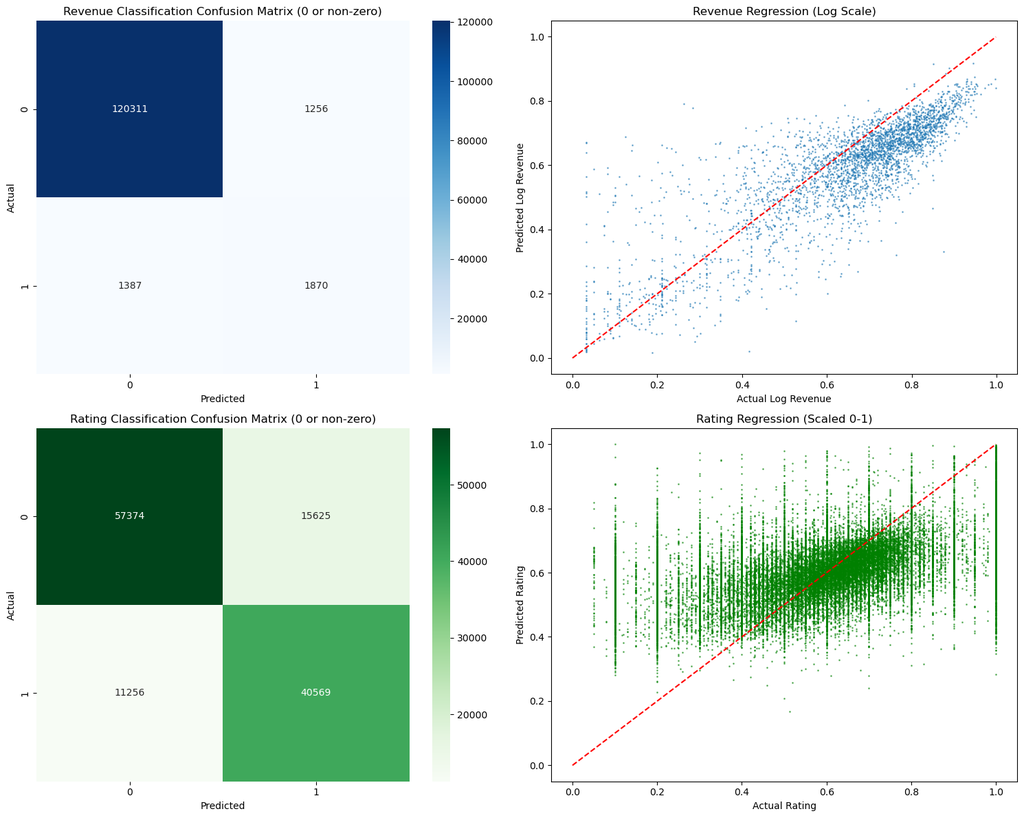

```python
plot_performance(test_results)
```

Here we can clearly see the sigificant zero-inflation in revenue. But, we can also see that the model seems to do pretty well with the regression and does very well with catching zeros.

Now we can also plot the loss over the epochs.

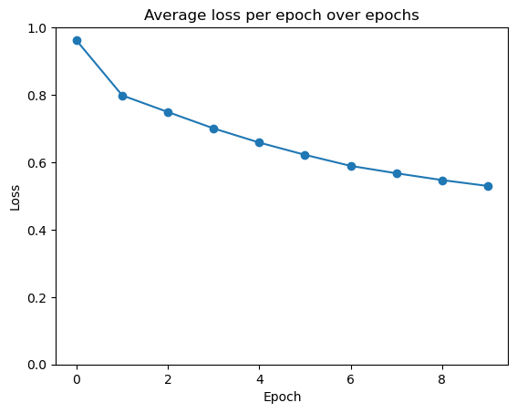

```python
plt.plot(losses, 'o-')
plt.title("Average loss per epoch over epochs")
plt.xlabel("Epoch")
plt.ylabel("Loss")
plt.ylim(0, 1)
plt.show()
```

We can also plot the performance of the model on our new data.

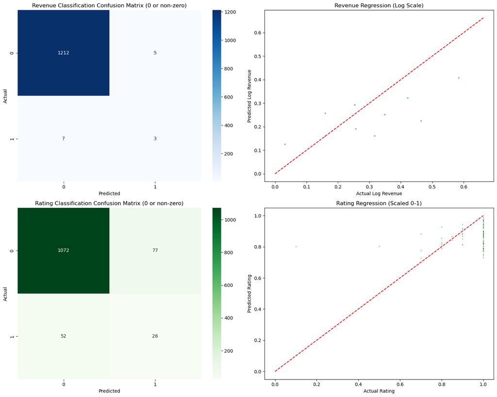

```python
plot_performance(test_results2)
```

It's much the same story as the test data set, the model catches most of the zeros, but struggles with the positive case. Maybe even more so with the new data since the new data had more empty features, especially in the text than the original data, which has more time to be filled out.

# Insights and Conclusions

The overall goal of our movie dataset analysis is to understand how different components of a movie, such as popularity score, date released, or movie budget, can affect the average rating and revenue of a movie, and to be able to create a model that can predict rating and revenue for future movies. In order to make full use of these metrics, we needed to turn these metrics into a usable form, formatting dates, removing extraneous columns, and embedding the text variables into dense vectors using distilbert. We then cleaned the data, removing nonsensical values, like movies with a runtime of 0, and also removing rows which lacked values that we could not fix through imputation, like the missing dates. Scaling and transforming of the data was also performed since the range of the values of the various numeric columns in our data varied quite a bit and we didn’t want that to bias the final model. We also filled in missing text fields with empty strings after noticing that the missing values in the text fields were Missing at Random, and thus shouldn’t be discarded.

What we found through this process is that using relatively basic features you can actually build a model that can relatively, reliably predict movie revenues and vote averages. Despite the significant challenges of the zero-inflated targets to the classification, the regression part of the model managed to remain quite reliable.

If we could further extend our work, we would want to add other, very important features, like marketing budget, famous actors in the cast, directors, etc. Many of these features would likely be highly correlated with a movie's revenue and rating, especially marketing budget. The fact that our model performed as well as it did without such important features is quite interesting.